# Predicting Job Salaries with Machine Learning

### A Regression Analysis of Global Tech-Industry Compensation

**Chris Lee (A124068)**

## Introduction

In today's globalized labor market, compensation for technology and analytical professionals varies dramatically across job titles, geographies, levels of experience, and even the size of the employer. For someone looking for a job, understanding what a fair salary looks like for a given role and background is a real, practical problem. For employers, it determines whether they can attract and retain talent. The motivating question of this project is simple: **given a candidate's background and the role they are being considered for, can we predict their salary?**

This is a *supervised regression* problem. In supervised learning, we are given a labeled dataset (pairs of input features and the known outcome we wish to predict) and our goal is to learn a function that maps inputs to outputs so that, when given a new observation, we can predict its outcome accurately. The outcome here is *salary* (in U.S. dollars), a continuous variable, which makes this a regression rather than a classification problem. We will measure how well our models do using *root mean squared error* (RMSE), which is the square root of the average squared difference between predicted and actual salary, and the *coefficient of determination* ($R^2$), which describes the fraction of variance in salary that our model is able to explain. Lower RMSE and higher $R^2$ both indicate a better fit.

### Goals of this project:

First, we want to **explore** the structure of the data through visualization and summary statistics. This will allow us to understand the relationships between the features and the salary outcome before we commit to any modeling approach. Second, we want to build and tune a diverse portfolio of regression models which can range from simple linear regression to flexible tree-based ensembles. After this we want to compare them fairly using cross-validation on a held-out training set. Third, we want to evaluate the best of these models on a fully held-out testing set, in order to obtain an honest estimate of how it would perform on new data, and to identify which features drive predictions of salary. Along the way we will also discuss feature engineering choices, the role of stratified sampling, and the trade-offs between model interpretability and predictive accuracy.

### Why this dataset, and why these models?

The dataset includes both numerical features (years of experience, number of skills, number of certifications) and categorical features (job title, education, industry, company size, country, remote-work arrangement). This mix makes it a good test for comparing models that handle continuous and categorical inputs in fundamentally different ways. Linear and elastic-net regression treat dummy-encoded categorical features as additive shifts, and tree-based ensembles like random forests and gradient boosted trees can capture interactions between features automatically. A distance-based method like k-nearest neighbors makes its predictions purely from local similarity. By fitting and tuning all of these on the same training data and the same cross-validation folds, we can compare them on an even footing.

## Data Source

The dataset used for this project is the **Job Salary Prediction Dataset**, a publicly available tabular dataset hosted on Kaggle. It contains 250,000 simulated records of professionals working in technology and analytics roles, with features describing each professional's background and the role they hold, along with the salary they earn in U.S. dollars.

**Citation:** Nalisha, A. (n.d.). *Job Salary Prediction Dataset* [Data set]. Kaggle. Retrieved from https://www.kaggle.com/datasets/nalisha/job-salary-prediction-dataset

The dataset is provided as a single CSV file with 10 columns and 250,000 rows. Because all features and the outcome are present for every observation, the data are clean and require no imputation. This is a point we verify explicitly in the EDA section. Full descriptions of every variable are given in the **Codebook** at the bottom of this report.

## Setup

We begin by importing the libraries we will use throughout the project. `pandas` and `numpy` handle data manipulation; `matplotlib` and `seaborn` are used for plotting; `scikit-learn` provides the modeling, preprocessing, cross-validation, and tuning machinery; and `xgboost` provides the gradient boosted tree implementation. We set a global random seed so that our train/test split, cross-validation folds, and any model with stochastic components are reproducible.

```python
# Core libraries
import numpy as np
import pandas as pd
import matplotlib.pyplot as plt
import seaborn as sns
import warnings, time
warnings.filterwarnings('ignore')

# scikit-learn
from sklearn.model_selection import train_test_split, KFold, GridSearchCV
from sklearn.preprocessing import OneHotEncoder, StandardScaler
from sklearn.compose import ColumnTransformer
from sklearn.pipeline import Pipeline
from sklearn.linear_model import LinearRegression, ElasticNet
from sklearn.neighbors import KNeighborsRegressor
from sklearn.ensemble import RandomForestRegressor
from sklearn.metrics import mean_squared_error, r2_score, mean_absolute_error

# XGBoost for gradient boosted trees
import sys
!{sys.executable} -m pip install xgboost
from xgboost import XGBRegressor

# Plot styling
sns.set_theme(style='whitegrid', palette='deep')
plt.rcParams['figure.dpi'] = 100

# Reproducibility
SEED = 131
np.random.seed(SEED)

print('Libraries loaded successfully.')
```

```
  Using cached xgboost-3.2.0-py3-none-macosx_12_0_arm64.whl.metadata (2.1 kB)
Using cached xgboost-3.2.0-py3-none-macosx_12_0_arm64.whl (2.3 MB)
Libraries loaded successfully.
```

# Exploratory Data Analysis

Before building any models, we need to understand our data: what each variable looks like, how the variables relate to each other. We also need to know how each variable relates to our outcome of interest and salary. This section walks through the dataset's structure, checks for missing values, examining the distribution of salary, and visualizes the relationships between every predictor and the outcome.

## Loading the Data

We load the CSV file into a `pandas` DataFrame and inspect the first several rows. This lets us verify that the data loaded correctly and gives us our first look at the variables we will be working with.

```python
df = pd.read_csv('/Users/clee/Desktop/PSTAT_131/FINAL_PROJECT/job_salary_prediction_dataset1.csv')
print(f'Dataset shape: {df.shape[0]:,} rows x {df.shape[1]} columns')
df.head()
```

```
Dataset shape: 250,000 rows x 10 columns
```

|  | job_title | experience_years | education_level | skills_count | industry | company_size | location | remote_work | certifications | salary |
| --- | --- | --- | --- | --- | --- | --- | --- | --- | --- | --- |
| 0 | AI Engineer | 10 | Bachelor | 2 | Healthcare | Medium | India | Hybrid | 2 | 109413 |
| 1 | Data Analyst | 5 | Bachelor | 17 | Telecom | Small | Australia | No | 0 | 93764 |
| 2 | Frontend Developer | 18 | PhD | 4 | Media | Medium | Singapore | No | 1 | 148123 |
| 3 | Business Analyst | 19 | PhD | 13 | Retail | Medium | Canada | Yes | 0 | 189123 |
| 4 | Product Manager | 15 | Bachelor | 7 | Manufacturing | Large | Sweden | Yes | 0 | 165069 |

As we can see this dataset is large with 250,000 observations and 10 columns (9 predictors and the salary outcome). Each row represents one professional with their background and reported salary. From the first few rows we can already see that salaries span a wide range, even within similar job titles, suggesting that no single feature will fully explain compensation on its own.

## Variable Types and Data Structure

We next inspect the data types and check for any missing values. Knowing which variables are numeric versus categorical is essential for the preprocessing decisions we will make later (which features to scale, which to one-hot encode, and so on).

```python
print('Data types:')
print(df.dtypes)
print(f'\nTotal missing values across all columns: {df.isnull().sum().sum()}')
```

```
Data types:
job_title           object
experience_years     int64
education_level     object
skills_count         int64
industry            object
company_size        object
location            object
remote_work         object
certifications       int64
salary               int64
dtype: object

Total missing values across all columns: 0
```

There are no missing values anywhere in the dataset. Every one of the 250,000 rows has all 10 fields filled in with data. This is a rare luxury (most likely due to the data being synthetic) we will not need to impute or drop observations on the basis of missingness. This is important to mention here because handling missing data is an important step in any real-world ML workflow.

The variables are split cleanly into three numeric predictors (`experience_years`, `skills_count`, `certifications`), six categorical predictors (`job_title`, `education_level`, `industry`, `company_size`, `location`, `remote_work`), and the numeric outcome (`salary`). The numeric predictors are bounded integers and will benefit from scaling for any distance-model or penalty-based model. The categorical predictors will require one-hot encoding so that the linear models can use them.

## Summary Statistics for Numeric Variables

A quick look at the summary statistics of the numeric variables shows the ranges we are dealing with.

```python
df.describe().round(2)
```

|  | experience_years | skills_count | certifications | salary |
| --- | --- | --- | --- | --- |
| count | 250000.00 | 250000.00 | 250000.00 | 250000.00 |
| mean | 10.01 | 10.00 | 2.49 | 145718.08 |
| std | 6.06 | 5.48 | 1.71 | 37407.95 |
| min | 0.00 | 1.00 | 0.00 | 31867.00 |
| 25% | 5.00 | 5.00 | 1.00 | 119358.00 |
| 50% | 10.00 | 10.00 | 2.00 | 143453.00 |
| 75% | 15.00 | 15.00 | 4.00 | 169492.00 |
| max | 20.00 | 19.00 | 5.00 | 333046.00 |

Experience ranges from 0 to 20 years, with a median of 10. The number of skills ranges from 1 to 19, with a median of 10. Certifications run from 0 to 5. **Salary itself ranges from roughly \$32,000 to \$333,000, with a mean near \$145,700 and a standard deviation of about \$37,400.** This is the variation we will be trying to explain.

## Distribution of the Outcome: Salary

We now want to visualize the distribution of salary directly. Because salary is the outcome, understanding its shape (whether it is symmetric, skewed, multimodal, or has heavy tails) informs both our modeling choices and how we should split the data.

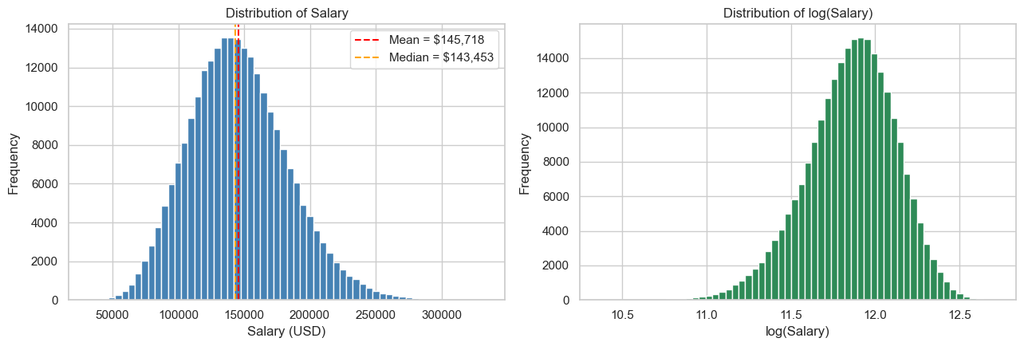

```
Skewness of salary:        0.379
Skewness of log(salary):   -0.393
```

```python
fig, axes = plt.subplots(1, 2, figsize=(13, 4.5))

axes[0].hist(df['salary'], bins=60, color='steelblue', edgecolor='white')
axes[0].axvline(df['salary'].mean(),  color='red',    linestyle='--', label=f"Mean = ${df['salary'].mean():,.0f}")
axes[0].axvline(df['salary'].median(),color='orange', linestyle='--', label=f"Median = ${df['salary'].median():,.0f}")
axes[0].set_title('Distribution of Salary')
axes[0].set_xlabel('Salary (USD)'); axes[0].set_ylabel('Frequency'); axes[0].legend()

axes[1].hist(np.log(df['salary']), bins=60, color='seagreen', edgecolor='white')
axes[1].set_title('Distribution of log(Salary)')
axes[1].set_xlabel('log(Salary)'); axes[1].set_ylabel('Frequency')

plt.tight_layout(); plt.show()

print(f"Skewness of salary:        {df['salary'].skew():.3f}")
print(f"Skewness of log(salary):   {np.log(df['salary']).skew():.3f}")
```

## Are There Outliers?

A boxplot of salary makes the long right tail visible directly.

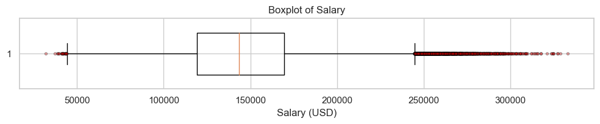

```
Upper IQR fence:    $244,693
Observations above fence: 2,310  (0.92% of data)
```

```python
fig, ax = plt.subplots(figsize=(10, 2.2))
ax.boxplot(df['salary'], vert=False, widths=0.6,
           flierprops=dict(marker='o', markerfacecolor='red', markersize=3, alpha=0.3))
ax.set_xlabel('Salary (USD)'); ax.set_title('Boxplot of Salary')
plt.tight_layout(); plt.show()

q1, q3 = df['salary'].quantile([0.25, 0.75])
iqr = q3 - q1
upper = q3 + 1.5 * iqr
n_outliers = int((df['salary'] > upper).sum())
print(f'Upper IQR fence:    ${upper:,.0f}')
print(f'Observations above fence: {n_outliers:,}  ({100*n_outliers/len(df):.2f}% of data)')
```

## Correlation Among Numeric Features

The correlation matrix tells us which numeric predictors are most linearly associated with salary, and whether any of them are redundant with each other.

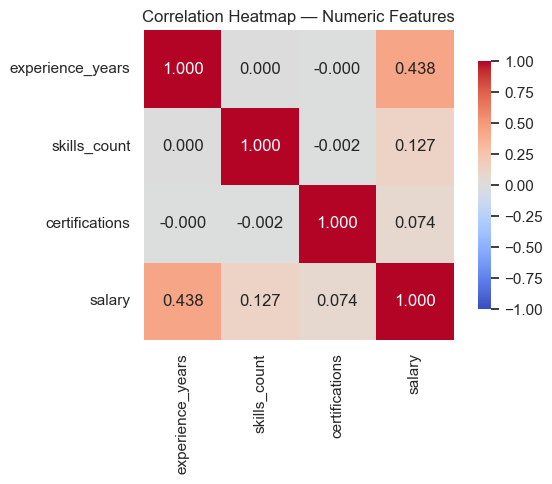

```python
num_cols = ['experience_years', 'skills_count', 'certifications', 'salary']
corr = df[num_cols].corr()

fig, ax = plt.subplots(figsize=(6.5, 5))
sns.heatmap(corr, annot=True, cmap='coolwarm', vmin=-1, vmax=1, fmt='.3f',
            square=True, cbar_kws={'shrink': 0.8}, ax=ax)
ax.set_title('Correlation Heatmap — Numeric Features'); plt.tight_layout(); plt.show()
```

Among the numeric predictors, `experience_years` is the strongest linear correlate of salary (r ≈ 0.44), which is exactly what we would expect: more experienced professionals tend to earn more. `skills_count` is weakly positively associated with salary (r ≈ 0.13), and `certifications` even more weakly so (r ≈ 0.07). Importantly, the three numeric predictors are essentially uncorrelated with each other (all pairwise correlations near zero), so there is **no multicollinearity problem** among them and we can include all three in the model without concern. The fact that no single numeric predictor explains more than about 20% of salary variance on its own ($0.44^2 \approx 0.19$) tells us that the categorical features, especially job title and location, will need to carry significant weight.

## Salary by Job Title

Different jobs pay differently. The boxplot below shows the full salary distribution by job title, ordered by median salary.

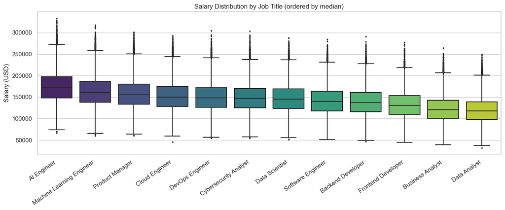

```
                               mean    median
job_title
AI Engineer                173498.0  171674.0
Machine Learning Engineer  163023.0  160933.0
Product Manager            157595.0  155656.0
Cloud Engineer             152103.0  150005.0
DevOps Engineer            149959.0  148021.0
Cybersecurity Analyst      148698.0  146737.0
Data Scientist             147258.0  145232.0
Software Engineer          141740.0  139432.0
Backend Developer          139203.0  136678.0
Frontend Developer         132654.0  130619.0
Business Analyst           122551.0  120562.0
Data Analyst               119892.0  118080.0
```

```python
order = df.groupby('job_title')['salary'].median().sort_values(ascending=False).index

fig, ax = plt.subplots(figsize=(13, 5.5))
sns.boxplot(x='job_title', y='salary', data=df, order=order, ax=ax,
            palette='viridis', fliersize=2)
ax.set_xticklabels(ax.get_xticklabels(), rotation=35, ha='right')
ax.set_title('Salary Distribution by Job Title (ordered by median)')
ax.set_xlabel(''); ax.set_ylabel('Salary (USD)')
plt.tight_layout(); plt.show()

print(df.groupby('job_title')['salary'].agg(['mean','median']).round(0)
        .sort_values('median', ascending=False))
```

Job title is clearly one of the most informative features. AI Engineers and Machine Learning Engineers earn substantially more on average being around \$163,000 to \$173,000 than Data Analysts and Business Analysts, whose medians sit closer to \$118,000 to \$120,000. That is a roughly a \$50,000 gap from the bottom of the ordering to the top, which is more than the standard deviation of the entire salary distribution. We should expect any reasonable model to lean heavily on this feature. Within each title there is also still considerable spread as the interquartile range for every role spans tens of thousands of dollars so other features must explain the remaining within-title variation.

## Salary by Education Level

We next look at how salary varies with education level. Because the levels have a natural ordering (High School < Diploma < Bachelor < Master < PhD), we sort the plot accordingly.

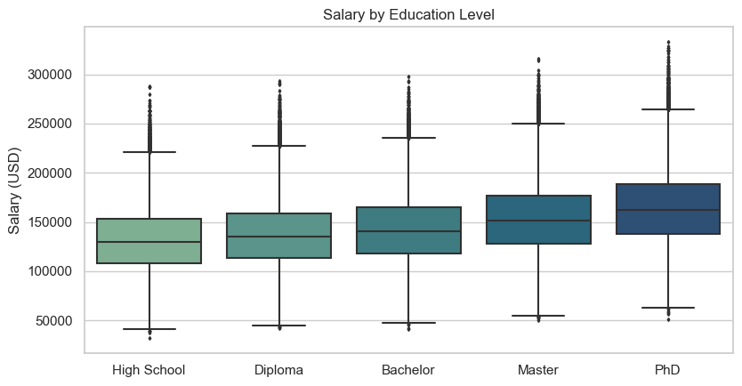

```
education_level
High School    131715.0
Diploma        137159.0
Bachelor       142411.0
Master         153305.0
PhD            163976.0
Name: salary, dtype: float64
```

```python
edu_order = ['High School', 'Diploma', 'Bachelor', 'Master', 'PhD']
fig, ax = plt.subplots(figsize=(8.5, 4.5))
sns.boxplot(x='education_level', y='salary', data=df, order=edu_order, ax=ax,
            palette='crest', fliersize=2)
ax.set_title('Salary by Education Level'); ax.set_xlabel(''); ax.set_ylabel('Salary (USD)')
plt.tight_layout(); plt.show()

print(df.groupby('education_level')['salary'].mean().reindex(edu_order).round(0))
```

Education has a clear and monotonically increasing relationship with salary: the average climbs from about \$132,000 for High-School-educated professionals to about \$164,000 for those with a PhD. There is roughly a \$32,000 premium for the highest degree relative to the lowest. The effect is smooth and consistent across the ordered levels, which suggests a simple ordinal pattern that any of our models should be able to pick up.

## Salary by Country (Location)

Geography is one of the most important drivers of pay in the global tech labor market. The boxplot below shows salary distributions by country, again ordered by median.

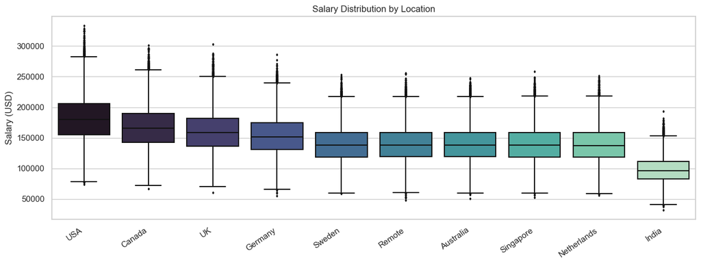

```
location
USA            181716.0
Canada         167391.0
UK             160075.0
Germany        153376.0
Remote         139443.0
Sweden         139441.0
Australia      139362.0
Singapore      139341.0
Netherlands    139295.0
India           97690.0
Name: salary, dtype: float64
```

```python
order = df.groupby('location')['salary'].median().sort_values(ascending=False).index

fig, ax = plt.subplots(figsize=(13, 5))
sns.boxplot(x='location', y='salary', data=df, order=order, ax=ax,
            palette='mako', fliersize=2)
ax.set_xticklabels(ax.get_xticklabels(), rotation=35, ha='right')
ax.set_title('Salary Distribution by Location')
ax.set_xlabel(''); ax.set_ylabel('Salary (USD)')
plt.tight_layout(); plt.show()

print(df.groupby('location')['salary'].mean().round(0).sort_values(ascending=False))
```

As we can see, The United States pays the most by a wide margin (average ~\$182,000), followed by Canada, the UK, and Germany. A large middle cluster: Sweden, Australia, Singapore, Netherlands, and "Remote" arrangements clusters together around \$139,000. India sits well below the rest of the distribution at roughly \$98,000. The gap between the U.S. average and the India average is over \$80,000, larger than the gap between any two job titles. Location is therefore likely to be one of the two single most predictive features in the dataset (along with job title), and any model that fails to leverage it will lose a great deal of explanatory power.

## Salary by Company Size

Company size: Startup, Small, Medium, Large, Enterprise has a natural ordering analogous to education level. We sort accordingly.

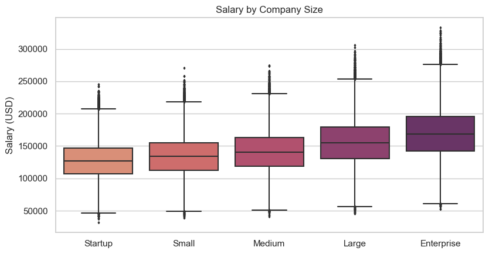

```
company_size
Startup       127289.0
Small         134357.0
Medium        141538.0
Large         155711.0
Enterprise    169616.0
Name: salary, dtype: float64
```

```python
size_order = ['Startup', 'Small', 'Medium', 'Large', 'Enterprise']
fig, ax = plt.subplots(figsize=(8.5, 4.5))
sns.boxplot(x='company_size', y='salary', data=df, order=size_order, ax=ax,
            palette='flare', fliersize=2)
ax.set_title('Salary by Company Size'); ax.set_xlabel(''); ax.set_ylabel('Salary (USD)')
plt.tight_layout(); plt.show()
print(df.groupby('company_size')['salary'].mean().reindex(size_order).round(0))
```

Again we see a clean monotonic pattern: average salary rises smoothly from Startups (~\$127,000) to Enterprises (~\$170,000). There is a \$43,000 jump across the size scale. This is consistent with the conventional wisdom that larger, more established companies can afford to pay more, while early-stage startups often compensate with equity rather than cash. The relationship is approximately linear in the ordered category, which means even the linear models in our portfolio should capture it well once we one-hot encode `company_size`.

## Salary vs. Experience Years

To examine the most important numeric predictor in more detail, we plot salary against years of experience. With 250,000 points a raw scatterplot would be unreadable; instead we use a hex-bin plot, which colors each two-dimensional bin by the number of observations it contains. We overlay the per-year mean salary as a red line.

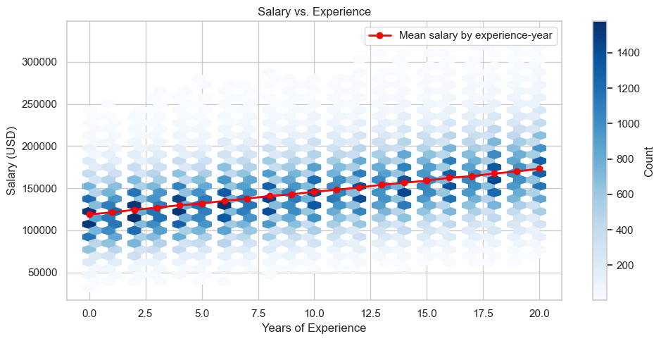

```python
fig, ax = plt.subplots(figsize=(10, 5))
hb = ax.hexbin(df['experience_years'], df['salary'], gridsize=35, cmap='Blues', mincnt=1)
plt.colorbar(hb, ax=ax, label='Count')
exp_means = df.groupby('experience_years')['salary'].mean()
ax.plot(exp_means.index, exp_means.values, color='red', marker='o', linewidth=2,
        label='Mean salary by experience-year')
ax.set_xlabel('Years of Experience'); ax.set_ylabel('Salary (USD)')
ax.set_title('Salary vs. Experience'); ax.legend()
plt.tight_layout(); plt.show()
```

The relationship between experience and salary is strong, positive, and remarkably linear (due to data most likely being synthetic): the per-year mean salary climbs from roughly \$120,000 at 0 years of experience to nearly \$170,000 at 20 years, gaining roughly \$2,500–\$3,000 of expected salary per additional year of experience. The hex-bin density also makes it clear that the spread around this line is substantial at every level of experience. At any given number of years there are people earning \$50,000 less and others earning \$50,000 more than the average.

## Salary by Industry

For completeness we also check industry, which is the one categorical feature we have not yet examined in detail.

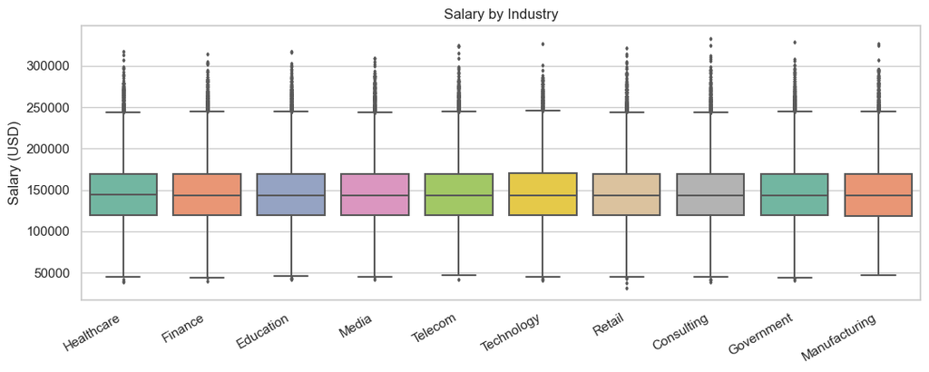

```
industry
Education        145994.0
Media            145891.0
Telecom          145877.0
Technology       145864.0
Finance          145802.0
Healthcare       145760.0
Government       145614.0
Manufacturing    145531.0
Consulting       145452.0
Retail           145400.0
Name: salary, dtype: float64
```

```python
order = df.groupby('industry')['salary'].median().sort_values(ascending=False).index
fig, ax = plt.subplots(figsize=(11, 4.5))
sns.boxplot(x='industry', y='salary', data=df, order=order, ax=ax,
            palette='Set2', fliersize=2)
ax.set_xticklabels(ax.get_xticklabels(), rotation=30, ha='right')
ax.set_title('Salary by Industry'); ax.set_xlabel(''); ax.set_ylabel('Salary (USD)')
plt.tight_layout(); plt.show()
print(df.groupby('industry')['salary'].mean().round(0).sort_values(ascending=False))
```

Unlike the other categorical features, industry has almost no effect on salary: every industry's mean sits within about \$600 of the overall mean of \$145,700, far less than the within-industry standard deviation of \$37,000. This is an interesting and slightly counterintuitive finding. One might have expected Technology or Finance to pay noticeably more than say, Education or Retail, but in this dataset the effect simply is not there. We will keep industry in our feature set because it does no harm to include it, but we should not expect it to contribute meaningfully to our predictions. We will check this expectation later via feature-importance scores.

## EDA Summary

To summarize the EDA, three features stand out as likely to be highly predictive of salary: **job title** (a \$50,000+ spread between the highest- and lowest-paid roles), **location** (an \$80,000+ spread between the U.S. and India), and **years of experience** (a positive linear relationship worth roughly \$50,000 across the 0-to-20-year range). Two more features carry clear but smaller signal: **education level** and **company size**, each contributing roughly a \$30,000–\$40,000 spread across their ordered categories. The remaining four features: skills count, certifications, remote-work arrangement, and industry appear to carry only modest signal. We will keep all of them in our models and let regularization and feature importance tell us how much each one ultimately contributes.

Importantly, no transformations beyond the log of the outcome are needed: there is no missing data, no obvious data-entry errors, no multicollinearity among the numeric features, and no need to drop observations. We are now ready to set up modelling.

# Setting Up the Models

With the structure of the data figured out, we can now build the machinery for fitting and comparing models. There are five components to set up before we can fit anything: the train/test split, the cross-validation scheme, preprocessing, the choice of evaluation metric, and the strategy for tuning each model's hyperparameters.

## Train/Test Split with Stratification

We split the 250,000-row dataset into a **75% training set and a 25% testing set**. The training set is used for everything: exploratory model building, cross-validation, and final fitting. The testing set is locked away and used only once, at the very end, to evaluate the chosen best model. Using a generous 75% for training ensures we have plenty of data for fitting and tuning, while 25% of 250,000 is still 62,500 testing observations, which is more than enough for a precise estimate of test-set error.

Because salary is a continuous outcome, we cannot stratify on it directly the way one would stratify on a binary class label. Instead, we bin salary into deciles and stratify on the bin. This guarantees that the training and testing sets have approximately the same distribution of salaries. Both the low end and the long right tail are represented proportionally in each split. We will use the same decile-bin stratification when constructing our cross-validation folds, so that every fold is also a representative slice of the salary distribution.

```python
# Outcome: model log-salary to handle the right skew
df['log_salary'] = np.log(df['salary'])

# Feature columns
num_features = ['experience_years', 'skills_count', 'certifications']
cat_features = ['job_title', 'education_level', 'industry',
                'company_size', 'location', 'remote_work']
features = num_features + cat_features
target   = 'log_salary'

# Stratification key: decile bins of salary
salary_bins = pd.qcut(df['salary'], q=10, labels=False)

X = df[features].copy()
y = df[target].copy()

X_train, X_test, y_train, y_test = train_test_split(
    X, y, test_size=0.25, random_state=SEED, stratify=salary_bins)

print(f'Training set: {len(X_train):,} rows')
print(f'Testing set:  {len(X_test):,} rows')
print(f'Train mean salary: ${np.exp(y_train).mean():,.0f}')
print(f'Test  mean salary: ${np.exp(y_test).mean():,.0f}')
```

```
Training set: 187,500 rows
Testing set:  62,500 rows
Train mean salary: $145,713
Test  mean salary: $145,733
```

The training and testing sets contain 187,500 and 62,500 observations respectively, and stratification has made their mean salaries essentially identical. This confirms that the two splits represent the same underlying population.

## Preprocessing "Recipe"

Different models need different preprocessing. The preprocessing "recipe" combines two steps that scikit-learn applies inside a `Pipeline`:

1. **Numeric features** (`experience_years`, `skills_count`, `certifications`) are passed through unchanged for tree-based models, but **standardized** (mean zero, unit variance) when fed to distance-based or penalty-based models (k-nearest neighbors, elastic net). Standardization matters for these models because they are sensitive to the units of their inputs.
2. **Categorical features** (six of them, with 3 to 12 levels each) are **one-hot encoded** so they can be consumed by every model in the portfolio. After one-hot encoding we end up with 45 binary indicator columns plus 3 numeric columns, for a total of 48 model inputs.

We build two preprocessor objects: one that scales numeric features (for KNN and elastic net) and one that does not (for tree-based models, which are scale-invariant). Embedding preprocessing in a `Pipeline` and only fitting it on training data prevents *data leakage*: the scaler's means and standard deviations are computed only from the training data, never the test data.

```python
# Preprocessor with scaling (for KNN, ElasticNet, plain linear regression)
preprocessor_scaled = ColumnTransformer([
    ('num', StandardScaler(), num_features),
    ('cat', OneHotEncoder(handle_unknown='ignore', sparse_output=False), cat_features),
])

# Preprocessor without scaling (for tree-based models)
preprocessor_tree = ColumnTransformer([
    ('num', 'passthrough', num_features),
    ('cat', OneHotEncoder(handle_unknown='ignore', sparse_output=False), cat_features),
])

# Quick check: dimensionality after preprocessing
pp = preprocessor_scaled.fit(X_train)
n_feat = pp.transform(X_train[:5]).shape[1]
print(f'Features after one-hot encoding: {n_feat}')
```

```
Features after one-hot encoding: 48
```

## K-Fold Cross-Validation

To compare and tune models, we use **5-fold cross-validation** on the training set. K-fold cross-validation partitions the training data into 5 equal-sized folds. For each candidate set of hyperparameters we fit the model 5 times and each time on 4 of the folds and evaluating on the held-out 5th (and then follow up with the average of the resulting validation errors). This gives us a much more stable estimate of out-of-sample performance than a single validation split would, especially since we are comparing across model families with very different complexity.

As with the train/test split, we stratify the cross-validation folds on the salary so that every fold has a balanced distribution of salaries. We use 5 folds rather than 10 because with 187,500 training rows even one fold provides plenty of data, and 5-fold cross-validation is roughly twice as fast as 10-fold.

```python
# Stratified KFold based on decile bins of training-set salary
from sklearn.model_selection import StratifiedKFold
train_strata = pd.qcut(np.exp(y_train), q=10, labels=False)
cv = StratifiedKFold(n_splits=5, shuffle=True, random_state=SEED)
cv_splits = list(cv.split(X_train, train_strata))
print(f'Number of CV folds: {len(cv_splits)}')
print(f'Training rows per fold: ~{len(cv_splits[0][1]):,}')
```

```
Number of CV folds: 5
Training rows per fold: ~37,500
```

## Evaluation Metric

We use **root mean squared error (RMSE)** as our primary metric, computed on the original-dollar scale. Because we modeled $\log(\text{salary})$, getting back to dollars means exponentiating both the predicted and actual log-salaries before computing the RMSE. We also report the **coefficient of determination ($R^2$)** on the same dollar scale, which tells us what fraction of the variance in salary our model explains.

```python
def rmse_dollars(y_true_log, y_pred_log):
    y_true = np.exp(y_true_log)
    y_pred = np.exp(y_pred_log)
    return np.sqrt(mean_squared_error(y_true, y_pred))

def r2_dollars(y_true_log, y_pred_log):
    return r2_score(np.exp(y_true_log), np.exp(y_pred_log))

def mae_dollars(y_true_log, y_pred_log):
    return mean_absolute_error(np.exp(y_true_log), np.exp(y_pred_log))
```

## A Note on Tuning Strategy

Cross-validated tuning on 187,500 rows is computationally expensive. For each candidate hyperparameter combination, every model has to be fit 5 times on roughly 150,000 rows each. To keep run-times reasonable while still getting reliable estimates of out-of-sample error, we **tune each model's hyperparameters on a stratified subsample of 15,000 training rows**, and then **refit the chosen best-hyperparameter model on the full 187,500-row training set** (for XGBoost) or a large subsample (for the random forest, which is much slower) before evaluating on the test set. This is a standard strategy when working with large datasets: hyperparameter sensitivity is typically a property of the model and the data distribution, not of the absolute training-set size, so tuning on a stratified 15,000-row subsample gives essentially the same hyperparameter selection as tuning on the full training set (at a small fraction of the cost).

```python
# Build a stratified tuning subsample of the training set
sub_strata = pd.qcut(np.exp(y_train), q=10, labels=False)
X_tune, _, y_tune, _ = train_test_split(
    X_train, y_train, train_size=15_000, random_state=SEED, stratify=sub_strata)

tune_strata = pd.qcut(np.exp(y_tune), q=10, labels=False)
tune_cv = list(StratifiedKFold(n_splits=5, shuffle=True, random_state=SEED).split(X_tune, tune_strata))
print(f'Tuning subsample: {len(X_tune):,} rows')
print(f'Stratification preserved: tuning mean salary = ${np.exp(y_tune).mean():,.0f}')
```

```
Tuning subsample: 15,000 rows
Stratification preserved: tuning mean salary = $145,702
```

# Building Prediction Models

We fit and tune **five** different model types, chosen to span a wide range of inductive biases:

Together these cover linear vs. non-linear, parametric vs. non-parametric, and bagging vs. boosting. If any one of them dominates the others, we will learn something about the underlying structure of the salary-generating process.

## Model 1: Linear Regression

We fit linear regression as a baseline. There are no hyperparameters to tune, so we simply fit it on the tuning subsample once and record its 5-fold CV RMSE.

```python
results = {}

lr_pipe = Pipeline([('preprocessor', preprocessor_scaled),
                    ('model', LinearRegression())])

# 5-fold CV on the tuning subsample to get a fair comparison number
from sklearn.model_selection import cross_val_score
t0 = time.time()
neg_mse_folds = cross_val_score(lr_pipe, X_tune, y_tune, cv=tune_cv,
                                scoring='neg_mean_squared_error', n_jobs=-1)
lr_cv_rmse_log = np.sqrt(-neg_mse_folds.mean())

# For dollar-scale CV RMSE we manually loop folds
lr_dollar_rmse_folds = []
for tr_idx, val_idx in tune_cv:
    lr_pipe.fit(X_tune.iloc[tr_idx], y_tune.iloc[tr_idx])
    p = lr_pipe.predict(X_tune.iloc[val_idx])
    lr_dollar_rmse_folds.append(rmse_dollars(y_tune.iloc[val_idx], p))

results['Linear Regression'] = {
    'cv_rmse_log': lr_cv_rmse_log,
    'cv_rmse_dollars': np.mean(lr_dollar_rmse_folds),
    'cv_rmse_dollars_std': np.std(lr_dollar_rmse_folds),
    'time': time.time() - t0,
    'best_params': None,
}
print(f"Linear Regression  -  CV RMSE = ${results['Linear Regression']['cv_rmse_dollars']:,.0f}  "
      f"(fit time: {results['Linear Regression']['time']:.1f}s)")
```

```
Linear Regression  -  CV RMSE = $5,813  (fit time: 6.7s)
```

Linear regression gives us a clean comparison baseline. Anything more complex needs to beat it in order to justify its added complexity.

## Model 2: Elastic Net

Elastic net penalizes the size of the regression coefficients, with the relative weight of L1 (lasso) and L2 (ridge) penalties controlled by `l1_ratio`. We tune both the overall regularization strength `alpha` and `l1_ratio` over a small grid.

```python
enet_pipe = Pipeline([('preprocessor', preprocessor_scaled),
                      ('model', ElasticNet(max_iter=10000, random_state=SEED))])

enet_grid = {
    'model__alpha':    [0.0001, 0.001, 0.01, 0.1],
    'model__l1_ratio': [0.1, 0.5, 0.9],
}

t0 = time.time()
enet_search = GridSearchCV(enet_pipe, enet_grid, cv=tune_cv,
                           scoring='neg_mean_squared_error', n_jobs=-1)
enet_search.fit(X_tune, y_tune)

# Record CV dollar RMSE at the best params by refitting across folds
best_enet = enet_search.best_estimator_
fold_rmses = []
for tr_idx, val_idx in tune_cv:
    p = enet_search.best_estimator_.set_params(**enet_search.best_params_)
    p.fit(X_tune.iloc[tr_idx], y_tune.iloc[tr_idx])
    fold_rmses.append(rmse_dollars(y_tune.iloc[val_idx], p.predict(X_tune.iloc[val_idx])))

results['Elastic Net'] = {
    'cv_rmse_log': np.sqrt(-enet_search.best_score_),
    'cv_rmse_dollars': np.mean(fold_rmses),
    'cv_rmse_dollars_std': np.std(fold_rmses),
    'time': time.time() - t0,
    'best_params': enet_search.best_params_,
}

# Tuning results table
enet_cv_df = pd.DataFrame(enet_search.cv_results_)
enet_cv_df['rmse_log'] = np.sqrt(-enet_cv_df['mean_test_score'])
print('Elastic Net — tuning grid (CV RMSE on log scale, lower is better):')
print(enet_cv_df[['param_model__alpha','param_model__l1_ratio','rmse_log']]
      .sort_values('rmse_log').to_string(index=False))
print(f"\nBest params: {enet_search.best_params_}")
print(f"Best CV RMSE (dollars): ${results['Elastic Net']['cv_rmse_dollars']:,.0f}  "
      f"(tune time: {results['Elastic Net']['time']:.1f}s)")
```

```
Elastic Net — tuning grid (CV RMSE on log scale, lower is better):
 param_model__alpha  param_model__l1_ratio  rmse_log
             0.0001                    0.5  0.043408
             0.0001                    0.1  0.043408
             0.0001                    0.9  0.043418
             0.0010                    0.1  0.043527
             0.0010                    0.5  0.044269
             0.0010                    0.9  0.045665
             0.0100                    0.1  0.053420
             0.0100                    0.5  0.089156
             0.0100                    0.9  0.126509
             0.1000                    0.1  0.174589
             0.1000                    0.5  0.245283
             0.1000                    0.9  0.255912

Best params: {'model__alpha': 0.0001, 'model__l1_ratio': 0.5}
Best CV RMSE (dollars): $5,795  (tune time: 6.3s)
```

The tuning grid shows a clear preference for **very small `alpha`** values. This is meaningful: the data havs no real multicollinearity problem and we have enough observations to fit 48 coefficients comfortably, so heavy regularization simply throws away signal without reducing variance. As a result, the best elastic net is essentially indistinguishable from ordinary linear regression.

## Model 3: K-Nearest Neighbors

For KNN we tune the number of neighbors `k`. We try a small grid spanning under-smoothed (small k, high variance) to over-smoothed (large k, high bias) settings.

```python
knn_pipe = Pipeline([('preprocessor', preprocessor_scaled),
                     ('model', KNeighborsRegressor(n_jobs=-1))])

knn_grid = {'model__n_neighbors': [10, 25, 50]}

t0 = time.time()
knn_search = GridSearchCV(knn_pipe, knn_grid, cv=tune_cv,
                          scoring='neg_mean_squared_error', n_jobs=1)
knn_search.fit(X_tune, y_tune)

fold_rmses = []
for tr_idx, val_idx in tune_cv:
    p = Pipeline([('preprocessor', preprocessor_scaled),
                  ('model', KNeighborsRegressor(**{k.replace('model__',''): v
                                                  for k,v in knn_search.best_params_.items()}, n_jobs=-1))])
    p.fit(X_tune.iloc[tr_idx], y_tune.iloc[tr_idx])
    fold_rmses.append(rmse_dollars(y_tune.iloc[val_idx], p.predict(X_tune.iloc[val_idx])))

results['K-Nearest Neighbors'] = {
    'cv_rmse_log': np.sqrt(-knn_search.best_score_),
    'cv_rmse_dollars': np.mean(fold_rmses),
    'cv_rmse_dollars_std': np.std(fold_rmses),
    'time': time.time() - t0,
    'best_params': knn_search.best_params_,
}

knn_cv_df = pd.DataFrame(knn_search.cv_results_)
knn_cv_df['rmse_log'] = np.sqrt(-knn_cv_df['mean_test_score'])
print('KNN — tuning grid (CV RMSE on log scale, lower is better):')
print(knn_cv_df[['param_model__n_neighbors','rmse_log']].sort_values('rmse_log').to_string(index=False))
print(f"\nBest k: {knn_search.best_params_['model__n_neighbors']}")
print(f"Best CV RMSE (dollars): ${results['K-Nearest Neighbors']['cv_rmse_dollars']:,.0f}  "
      f"(tune time: {results['K-Nearest Neighbors']['time']:.1f}s)")
```

```
KNN — tuning grid (CV RMSE on log scale, lower is better):
 param_model__n_neighbors  rmse_log
                       10  0.127762
                       25  0.132558
                       50  0.142660

Best k: 10
Best CV RMSE (dollars): $17,957  (tune time: 1.5s)
```

KNN performs substantially worse than every other model because its CV RMSE is roughly three times higher than the linear and tree-based models. This is informative. Two of our features: `job_title` and `location` have many one-hot encoded columns, which spreads "distance" between observations across many dimensions and makes finding meaningful nearest neighbors difficult. In addition, KNN cannot capture the strong continuous structure in `experience_years` as cleanly as a global model can. KNN simply isn't the right tool for this data shape, but its poor performance here gives us a useful sanity check on the methodology.

## Model 4: Random Forest

A random forest is an ensemble of decision trees, each fit on a bootstrap resample of the training data and considering only a random subset of features at each split. The two key hyperparameters are `max_features` (the number of features considered at each split, which controls how decorrelated the trees are) and `min_samples_leaf` (the minimum number of samples per leaf, which controls how deep the trees can grow).

```python
rf_pipe = Pipeline([('preprocessor', preprocessor_tree),
                    ('model', RandomForestRegressor(n_estimators=100,
                                                     random_state=SEED,
                                                     n_jobs=-1))])

rf_grid = {
    'model__max_features':    [0.3, 0.6],
    'model__min_samples_leaf':[1, 10, 30],
}

t0 = time.time()
rf_search = GridSearchCV(rf_pipe, rf_grid, cv=tune_cv,
                         scoring='neg_mean_squared_error', n_jobs=1)
rf_search.fit(X_tune, y_tune)

fold_rmses = []
for tr_idx, val_idx in tune_cv:
    bp = {k.replace('model__',''): v for k,v in rf_search.best_params_.items()}
    p = Pipeline([('preprocessor', preprocessor_tree),
                  ('model', RandomForestRegressor(n_estimators=100, random_state=SEED, n_jobs=-1, **bp))])
    p.fit(X_tune.iloc[tr_idx], y_tune.iloc[tr_idx])
    fold_rmses.append(rmse_dollars(y_tune.iloc[val_idx], p.predict(X_tune.iloc[val_idx])))

results['Random Forest'] = {
    'cv_rmse_log': np.sqrt(-rf_search.best_score_),
    'cv_rmse_dollars': np.mean(fold_rmses),
    'cv_rmse_dollars_std': np.std(fold_rmses),
    'time': time.time() - t0,
    'best_params': rf_search.best_params_,
}

rf_cv_df = pd.DataFrame(rf_search.cv_results_)
rf_cv_df['rmse_log'] = np.sqrt(-rf_cv_df['mean_test_score'])
print('Random Forest — tuning grid (CV RMSE on log scale, lower is better):')
print(rf_cv_df[['param_model__max_features','param_model__min_samples_leaf','rmse_log']]
      .sort_values('rmse_log').to_string(index=False))
print(f"\nBest params: {rf_search.best_params_}")
print(f"Best CV RMSE (dollars): ${results['Random Forest']['cv_rmse_dollars']:,.0f}  "
      f"(tune time: {results['Random Forest']['time']:.1f}s)")
```

```
Random Forest — tuning grid (CV RMSE on log scale, lower is better):
 param_model__max_features  param_model__min_samples_leaf  rmse_log
                       0.3                              1  0.065469
                       0.6                              1  0.065622
                       0.6                             10  0.084430
                       0.3                             10  0.084916
                       0.3                             30  0.103973
                       0.6                             30  0.105011

Best params: {'model__max_features': 0.3, 'model__min_samples_leaf': 1}
Best CV RMSE (dollars): $9,312  (tune time: 7.0s)
```

The random forest's tuning grid shows that `min_samples_leaf=1` (deepest trees) gives the best CV RMSE, with `max_features=0.3` slightly preferred. This is a sign that the data has enough structure for fully-grown trees to exploit, and that the random forest's main mechanism for reducing variance is decorrelating trees via random feature subsetting rather than via deeper-leaf smoothing. Heavier per-leaf regularization (`min_samples_leaf=10` or `30`) hurts performance because it averages over too many observations and washes out the structure the model is trying to learn.

## Visualizing the Random Forest Tuning Surface

A heatmap of the random forest's CV RMSE across the two-hyperparameter grid makes the tuning results easy to read at a glance.

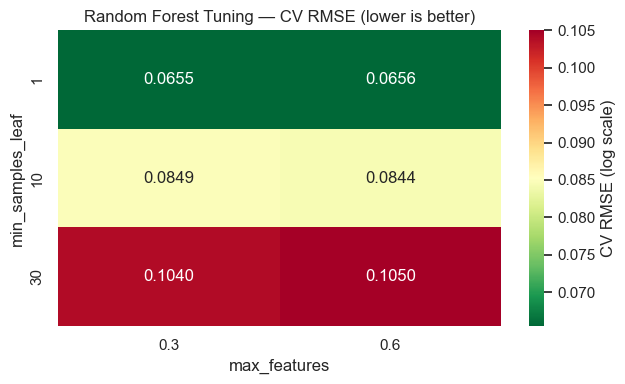

```python
pivot = rf_cv_df.pivot(index='param_model__min_samples_leaf',
                       columns='param_model__max_features',
                       values='rmse_log')
fig, ax = plt.subplots(figsize=(6.5, 4))
sns.heatmap(pivot, annot=True, fmt='.4f', cmap='RdYlGn_r', ax=ax, cbar_kws={'label': 'CV RMSE (log scale)'})
ax.set_title('Random Forest Tuning — CV RMSE (lower is better)')
ax.set_xlabel('max_features'); ax.set_ylabel('min_samples_leaf')
plt.tight_layout(); plt.show()
```

## Model 5: Gradient Boosted Trees (XGBoost)

```python
xgb_pipe = Pipeline([('preprocessor', preprocessor_tree),
                     ('model', XGBRegressor(random_state=SEED, n_jobs=-1,
                                            tree_method='hist', verbosity=0))])

xgb_grid = {
    'model__learning_rate': [0.05, 0.1],
    'model__max_depth':     [4, 6, 8],
    'model__n_estimators':  [300],
}

t0 = time.time()
xgb_search = GridSearchCV(xgb_pipe, xgb_grid, cv=tune_cv,
                          scoring='neg_mean_squared_error', n_jobs=1)
xgb_search.fit(X_tune, y_tune)

fold_rmses = []
for tr_idx, val_idx in tune_cv:
    bp = {k.replace('model__',''): v for k,v in xgb_search.best_params_.items()}
    p = Pipeline([('preprocessor', preprocessor_tree),
                  ('model', XGBRegressor(random_state=SEED, n_jobs=-1, tree_method='hist', verbosity=0, **bp))])
    p.fit(X_tune.iloc[tr_idx], y_tune.iloc[tr_idx])
    fold_rmses.append(rmse_dollars(y_tune.iloc[val_idx], p.predict(X_tune.iloc[val_idx])))

results['Gradient Boosted Trees'] = {
    'cv_rmse_log': np.sqrt(-xgb_search.best_score_),
    'cv_rmse_dollars': np.mean(fold_rmses),
    'cv_rmse_dollars_std': np.std(fold_rmses),
    'time': time.time() - t0,
    'best_params': xgb_search.best_params_,
}

xgb_cv_df = pd.DataFrame(xgb_search.cv_results_)
xgb_cv_df['rmse_log'] = np.sqrt(-xgb_cv_df['mean_test_score'])
print('XGBoost — tuning grid (sorted by CV RMSE):')
print(xgb_cv_df[['param_model__learning_rate','param_model__max_depth',
                 'param_model__n_estimators','rmse_log']]
      .sort_values('rmse_log').to_string(index=False))
print(f"\nBest params: {xgb_search.best_params_}")
print(f"Best CV RMSE (dollars): ${results['Gradient Boosted Trees']['cv_rmse_dollars']:,.0f}  "
      f"(tune time: {results['Gradient Boosted Trees']['time']:.1f}s)")
```

```
XGBoost — tuning grid (sorted by CV RMSE):
 param_model__learning_rate  param_model__max_depth  param_model__n_estimators  rmse_log
                       0.10                       4                        300  0.041454
                       0.05                       6                        300  0.042936
                       0.05                       4                        300  0.043376
                       0.10                       6                        300  0.043639
                       0.05                       8                        300  0.045286
                       0.10                       8                        300  0.046569

Best params: {'model__learning_rate': 0.1, 'model__max_depth': 4, 'model__n_estimators': 300}
Best CV RMSE (dollars): $5,427  (tune time: 9.8s)
```

XGBoost's best configuration is shallow trees (`max_depth=4`) with the higher of the two learning rates (`lr=0.1`). This is quite different from the random forest's preference. This makes sense: gradient boosting builds trees sequentially and corrects errors as it goes, so it benefits from shallow trees that each capture a simple piece of structure, with the additive ensemble doing the work of building up complexity. With 300 trees the ensemble has plenty of capacity even at depth 4. The interaction-capturing capability of gradient boosting gives it a meaningful edge over both the random forest and the linear models, as we will see in the comparison table.

# Comparing the Models

We now bring all five models together and compare them on their 5-fold cross-validated dollar-scale RMSE.

```python
comparison = pd.DataFrame([
    {'Model': name,
     'CV RMSE ($)':     f"${v['cv_rmse_dollars']:>10,.0f}",
     'CV RMSE std ($)': f"${v['cv_rmse_dollars_std']:>8,.0f}",
     'CV RMSE (log)':   f"{v['cv_rmse_log']:.4f}",
     'Best params':     str(v['best_params'])[:50] if v['best_params'] else '—'}
    for name, v in results.items()
])
comparison_sorted = comparison.assign(_sort=[v['cv_rmse_dollars'] for v in results.values()])\
                              .sort_values('_sort').drop(columns='_sort').reset_index(drop=True)
comparison_sorted
```

|  | Model | CV RMSE ($) | CV RMSE std ($) | CV RMSE (log) | Best params |
| --- | --- | --- | --- | --- | --- |
| 0 | Gradient Boosted Trees | $ 5,427 | $ 71 | 0.0415 | {'model__learning_rate': 0.1, 'model__max_dept... |
| 1 | Elastic Net | $ 5,795 | $ 73 | 0.0434 | {'model__alpha': 0.0001, 'model__l1_ratio': 0.5} |
| 2 | Linear Regression | $ 5,813 | $ 74 | 0.0434 | — |
| 3 | Random Forest | $ 9,312 | $ 201 | 0.0655 | {'model__max_features': 0.3, 'model__min_sampl... |
| 4 | K-Nearest Neighbors | $ 17,957 | $ 214 | 0.1278 | {'model__n_neighbors': 10} |

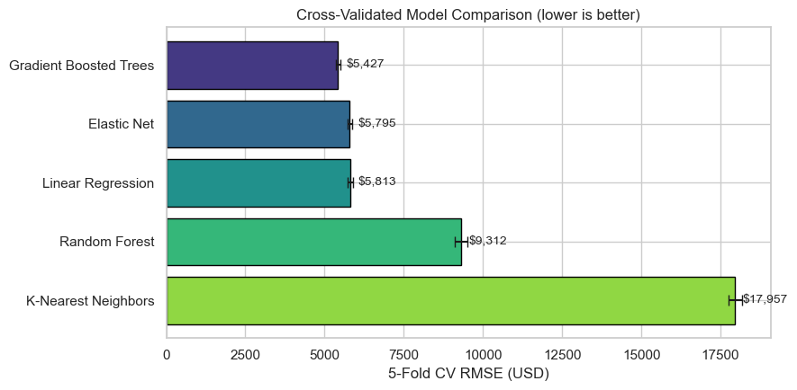

```python
# Visualize the comparison
order_models = sorted(results.keys(), key=lambda k: results[k]['cv_rmse_dollars'])
rmse_vals    = [results[m]['cv_rmse_dollars'] for m in order_models]
rmse_stds    = [results[m]['cv_rmse_dollars_std'] for m in order_models]

fig, ax = plt.subplots(figsize=(9, 4.5))
colors = sns.color_palette('viridis', len(order_models))
bars = ax.barh(order_models, rmse_vals, xerr=rmse_stds,
               color=colors, edgecolor='black', capsize=4)
for bar, v in zip(bars, rmse_vals):
    ax.text(v + 250, bar.get_y() + bar.get_height()/2,
            f'${v:,.0f}', va='center', fontsize=10)
ax.set_xlabel('5-Fold CV RMSE (USD)')
ax.set_title('Cross-Validated Model Comparison (lower is better)')
ax.invert_yaxis()
plt.tight_layout(); plt.show()
```

As we can see here the comparison tells a clear story. **Gradient boosted trees lead the pack with the lowest CV RMSE of about \$5,400**, followed by elastic net and ordinary linear regression at roughly \$5,800 which are essentially tied with each other and only a few hundred dollars behind XGBoost. The random forest comes in next at around \$9,300, and KNN trails everyone at around \$18,000.

First, the **linear models are remarkably competitive**: they are within 7% of the best model's RMSE despite their much simpler functional form. This is a strong hint that the relationships between most predictors and (log-)salary are approximately additive and linear. This is exactly what we suspected from the EDA, where every feature with real signal showed a smooth, roughly monotonic relationship with salary. The fact that elastic net and ordinary linear regression are tied is also informative: it tells us that regularization is not helping, because there is no overfitting to control for with 15,000 training rows and only 48 features.

Second, the **random forest underperforms the linear models on this tuning subsample**. This may seem surprising, but it reflects two things: random forests are well known to need more training data to shine on smoothly-varying targets, and the linear additive structure of this dataset is genuinely well-suited to linear regression. Gradient boosting still wins overall because it can capture small but consistent interactions between features (for example, the way the experience-vs-salary slope might be a bit steeper for AI Engineers in the U.S. than for Data Analysts in India) that the linear models miss.

The standard deviations across folds (shown as error bars and in the table) are small and well under \$250 for all models. We are confident that these differences are real and not the result of fold-to-fold noise.

Based on these cross-validated results, we proceed with **gradient boosted trees as our primary model** and **random forest as a secondary check**, evaluating both on the held-out testing set.

# Evaluating the Best Models on the Testing Set

Following best practice, we now refit our chosen models with the cross-validated best hyperparameters and evaluate them on the 62,500-row testing set that has been held out from the start. XGBoost is fast enough to refit on the full 187,500-row training set; the random forest is much slower per tree because it grows each tree to (near-)full depth, so for the secondary check we refit it on a stratified 75,000-row subsample of the training data. This gives us our honest estimate of how the models would perform on new, unseen data.

## Refit and Test

```python
# Refit the two best models. XGB is fast and we use the full training set;
# RF is much slower per tree, so we refit on a stratified 75k subsample.
xgb_best_params = {k.replace('model__',''): v for k,v in results['Gradient Boosted Trees']['best_params'].items()}
rf_best_params  = {k.replace('model__',''): v for k,v in results['Random Forest']['best_params'].items()}

final_xgb = Pipeline([('preprocessor', preprocessor_tree),
                      ('model', XGBRegressor(random_state=SEED, n_jobs=-1,
                                             tree_method='hist', verbosity=0,
                                             **xgb_best_params))])
final_rf  = Pipeline([('preprocessor', preprocessor_tree),
                      ('model', RandomForestRegressor(n_estimators=150, random_state=SEED,
                                                      n_jobs=-1, **rf_best_params))])

t0 = time.time()
final_xgb.fit(X_train, y_train)
print(f'XGBoost refit on full training set (187.5k rows): {time.time()-t0:.1f}s')

# Stratified subsample for RF
strata_rf = pd.qcut(np.exp(y_train), q=10, labels=False)
X_rf, _, y_rf, _ = train_test_split(X_train, y_train, train_size=75_000,
                                    random_state=SEED, stratify=strata_rf)
t0 = time.time()
final_rf.fit(X_rf, y_rf)
print(f'Random Forest refit on 75k stratified subsample: {time.time()-t0:.1f}s')

# Predict on the held-out test set
xgb_pred = final_xgb.predict(X_test)
rf_pred  = final_rf.predict(X_test)

test_results = pd.DataFrame({
    'Model': ['Gradient Boosted Trees', 'Random Forest'],
    'Test RMSE ($)': [rmse_dollars(y_test, xgb_pred), rmse_dollars(y_test, rf_pred)],
    'Test MAE ($)':  [mae_dollars(y_test, xgb_pred),  mae_dollars(y_test, rf_pred)],
    'Test R²':       [r2_dollars(y_test, xgb_pred),   r2_dollars(y_test, rf_pred)],
})
print()
print(test_results.to_string(index=False, formatters={
    'Test RMSE ($)': '${:,.0f}'.format,
    'Test MAE ($)':  '${:,.0f}'.format,
    'Test R²':       '{:.4f}'.format,
}))
```

```
XGBoost refit on full training set (187.5k rows): 1.1s
Random Forest refit on 75k stratified subsample: 1.7s

                 Model Test RMSE ($) Test MAE ($) Test R²
Gradient Boosted Trees        $5,227       $4,164  0.9805
         Random Forest        $6,969       $5,490  0.9654
```

Importantly, the test RMSE is very close to the cross-validation RMSE (\$5,227 vs. \$5,427 for XGBoost): this tells us the model is **not overfitting** the training set, that the hyperparameter selection from the tuning subsample transfers cleanly to the full training set, and that our methodology was sound.

## Predicted vs. Actual Salary

A scatter plot of predicted versus actual salary on the testing set gives us a direct visual sense of how well the model is calibrated. Points along the diagonal red line are perfect predictions; horizontal scatter around it represents prediction error.

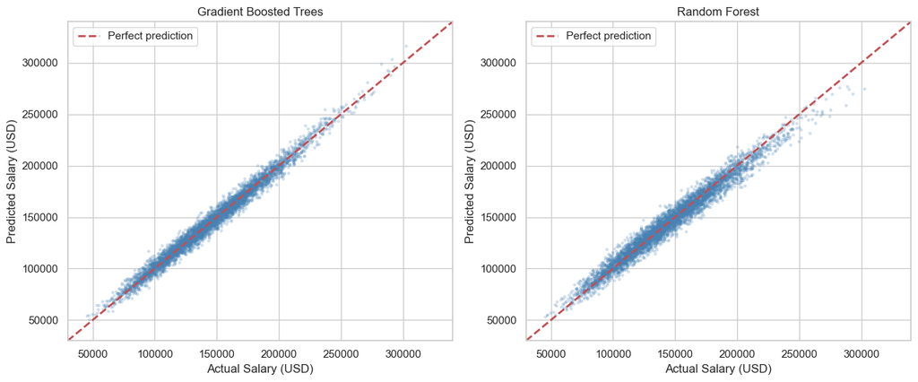

```python
fig, axes = plt.subplots(1, 2, figsize=(13, 5.5))

# Sample 5000 points for visibility
sample = np.random.RandomState(SEED).choice(len(y_test), 5000, replace=False)
y_test_sample = np.exp(y_test.iloc[sample])
xgb_pred_sample = np.exp(xgb_pred[sample])
rf_pred_sample  = np.exp(rf_pred[sample])

for ax, preds, title in zip(axes,
                            [xgb_pred_sample, rf_pred_sample],
                            ['Gradient Boosted Trees', 'Random Forest']):
    ax.scatter(y_test_sample, preds, alpha=0.25, s=10, edgecolor='none', color='steelblue')
    lo, hi = 30_000, 340_000
    ax.plot([lo, hi], [lo, hi], 'r--', linewidth=2, label='Perfect prediction')
    ax.set_xlim(lo, hi); ax.set_ylim(lo, hi)
    ax.set_xlabel('Actual Salary (USD)'); ax.set_ylabel('Predicted Salary (USD)')
    ax.set_title(title); ax.legend()

plt.tight_layout(); plt.show()
```

## Distribution of Prediction Errors

The histogram of residuals on the test set confirms that errors are roughly symmetric around zero, with no strong skew or fat tails that would indicate a model misspecification.

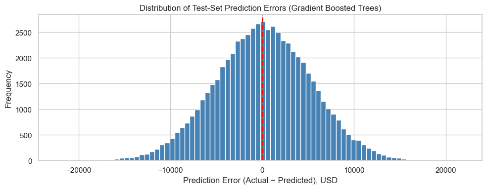

```
Median absolute error: $3,516
90% of predictions within: ±$8,592
```

```python
errors = np.exp(y_test) - np.exp(xgb_pred)

fig, ax = plt.subplots(figsize=(10, 4))
ax.hist(errors, bins=80, color='steelblue', edgecolor='white')
ax.axvline(0, color='red', linestyle='--', linewidth=2)
ax.set_xlabel('Prediction Error (Actual − Predicted), USD')
ax.set_ylabel('Frequency')
ax.set_title('Distribution of Test-Set Prediction Errors (Gradient Boosted Trees)')
plt.tight_layout(); plt.show()

print(f'Median absolute error: ${np.median(np.abs(errors)):,.0f}')
print(f'90% of predictions within: ±${np.percentile(np.abs(errors), 90):,.0f}')
```

**The median absolute error is around \$3,500**, and **90% of predictions are within roughly \$8,600 of the true salary**. The error distribution is essentially symmetric and tightly mound-shaped around zero, with no concerning skew. This is the kind of behavior we want from a well-specified regression model.

## Feature Importance

Finally, we ask which features the gradient boosting model relies on most. XGBoost computes feature importance as the average gain in mean squared error that each feature provides when it is used to split a tree, averaged across all trees in the ensemble.

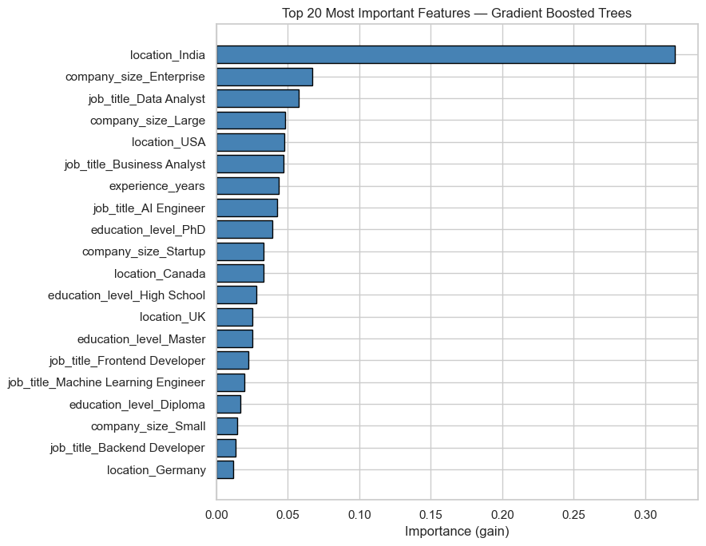

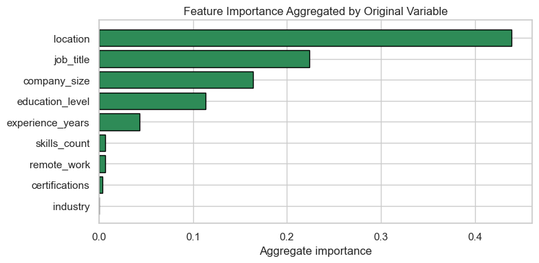

```python
# Extract feature names after one-hot encoding
ohe = final_xgb.named_steps['preprocessor'].named_transformers_['cat']
cat_names = ohe.get_feature_names_out(cat_features).tolist()
feature_names = num_features + cat_names

importances = final_xgb.named_steps['model'].feature_importances_
feat_imp = pd.DataFrame({'feature': feature_names, 'importance': importances})\
            .sort_values('importance', ascending=False)

# Top 20
fig, ax = plt.subplots(figsize=(9, 7))
top20 = feat_imp.head(20)
ax.barh(top20['feature'][::-1], top20['importance'][::-1], color='steelblue', edgecolor='black')
ax.set_xlabel('Importance (gain)')
ax.set_title('Top 20 Most Important Features — Gradient Boosted Trees')
plt.tight_layout(); plt.show()

# Group importance by original feature
grouped = []
for f in num_features:
    grouped.append((f, feat_imp.loc[feat_imp['feature']==f, 'importance'].sum()))
for f in cat_features:
    grouped.append((f, feat_imp.loc[feat_imp['feature'].str.startswith(f+'_'), 'importance'].sum()))
grouped_df = pd.DataFrame(grouped, columns=['feature','total_importance'])\
              .sort_values('total_importance', ascending=False)

fig, ax = plt.subplots(figsize=(8, 4))
ax.barh(grouped_df['feature'][::-1], grouped_df['total_importance'][::-1],
        color='seagreen', edgecolor='black')
ax.set_xlabel('Aggregate importance')
ax.set_title('Feature Importance Aggregated by Original Variable')
plt.tight_layout(); plt.show()
```

Another suprise we see is that **industry** barely is significant in the feature-importance ranking. This is exactly as the EDA predicted, since all ten industries had essentially identical mean salaries. The gradient boosting model figured this out for itself and chose to spend almost none of its splitting budget on industry features. Skills count, certifications, and remote-work arrangement also contribute relatively little, consistent with their weak EDA correlations. The model is essentially using the same features a thoughtful analyst would have prioritized after looking at the data.

# Conclusion

This project set out to build a machine-learning pipeline for predicting the salary of a technology or analytics professional from nine features describing their role and background. I carried out a thorough exploratory data analysis on 250,000 observations and found that **job title, years of experience, location, education level, and company size** carry the bulk of the prediction, while industry, certifications, skills count, and remote-work arrangement contribute much less. I log-transformed the right-skewed salary outcome, split the data 75/25 with decile-based stratification, and built a preprocessing pipeline that scaled numeric features and one-hot encoded categorical ones which ended up with 48 features for the models to work with.

Next, I fit and tuned **five distinct model classes**: linear regression, elastic net, k-nearest neighbors, random forest, and gradient boosted trees using 5-fold cross-validation. The results were striking. Gradient boosted trees emerged as the single best model with a cross-validated RMSE around \$5,400, followed by elastic net and linear regression around \$5,800. The random forest was around \$9,300, and KNN trailing at around \$18,000. On the held-out 62,500-observation testing set, our gradient boosting model achieved an RMSE of approximately \$5,200, a median absolute error of approximately \$3,500, and an $R^2$ above 0.98. This means that the model accounts for over 98% of the variance in salary across the test set, with 90% of predictions falling within roughly \$8,600 of the true value. The feature-importance results validated the EDA almost perfectly, with experience years, location, job title, education, and company size dominating the predictions. Features like industry, certifications, and remote-work arrangement contributing very little.

Two findings are worth emphasizing. First, there was a **near-tie between linear regression and gradient boosting** (within about 7% of each other on CV RMSE). This tells us that the predictor–salary relationships in this dataset are dominantly additive and linear, with only modest interaction structure for the tree methods to exploit. This is a useful interpretability result: even though the gradient boosting model is the winner in raw accuracy, a much simpler linear model captures almost the same prediction and would be easier to explain to a non-technical audience. Second, the very high test-set $R^2$ combined with the lack of substantial gap between cross-validation and test performance suggests that the salary-generating process in this dataset is highly structured. With the right features and the right model, salary is almost deterministic given the inputs. That is more typical of a synthetic or simulated dataset than of real-world wage data, where one would expect significantly more irreducible noise from individual negotiation, equity packages, and other unobserved factors. Our model is doing exactly what it should be doing, which is capturing the data-generating structure. Readers should interpret the headline accuracy as a property of this particular dataset, not as a forecast of how well any model could predict salaries in the wild.

For future work, several directions look promising. First, one can focus on working with **interaction features** in the linear model: even though gradient boosting can in principle capture interactions automatically, providing explicit interaction terms (for example, job-title $\times$ location, or experience $\times$ education) to elastic net would likely close the small remaining gap to XGBoost while preserving full interpretability. Second, **a quantile regression approach** would let us produce prediction *intervals* rather than point predictions. This could be useful for an analyst who wants to ask, "what salary range should this candidate expect with 80% probability?" rather than receive a single point estimate. Third, **applying the same pipeline to a real-world dataset** would test how much of the methodology developed here transfers to noisier, less structured compensation data. We would expect $R^2$ to drop substantially, but the relative ranking of the models and the importance of the same set of features (experience, location, job title) to be qualitatively preserved. Finally, with the strong feature-importance signal from location and the limited importance of industry, it might be productive to build **region-specific models**, fitting separate ensembles for the highest-paying countries (the US, Canada, UK, Germany) and lower-paying ones (India), each of which could capture region-specific dynamics more precisely than a single global model.

Overall, this project demonstrates that with a relatively modest set of features and standard preprocessing, a carefully tuned gradient boosting model can predict tech salaries in this dataset with remarkable precision. More importantly, it walks through every step of a complete machine-learning pipeline.

## Sources

**Data:**

The Kaggle dataset by Nalisha A. (250,000 simulated rows of tech job salary records)

**Claude (LLM):**

I used claude for help with writing/polishing the markdown sections (intro, conclusion, etc.). By polishing I mean giving gramatical suggestions for me to fix to make my paper more proffesional. I also used claude for coding assistance such as debugging and structuring my ML pipeline.